# GBI6 - BIOINFORMÁTICA

## **Pregunta 2 VISUALIZACION DE DATOS [5 PUNTOS]**

Para esta pregunta tiene que utilizar la data `df_long`.

### [1 PUNTO] 2.1 Cree la funcion `tcga_boxplots` para visualizar boxplots y jitterplots. El único parámetro de la función es `dataset`. La función debe crear un boxplot de los niveles de expresión para cada gen.

```r
# Escriba el código para crear la función tcga_boxplots
library(ggplot2)
## LA funcion tcga_boxplots tiene como parametro data set que es un data frame. Los resultados dados de la función es un grafico con el nivel de expresión de cada gen
tcga_boxplots <- function(dataset) {
  return(ggplot (dataset, aes(x = gen, y = expresion_level, col = gen)) + labs(x="Gen", y = "Expresion") + geom_boxplot())
}
```

### [0.5 PUNTOS] 2.2 Utilizando la función `lapply()` genera la lista `cancertype_boxplots` con las gráficas para cada tipo de cancer (cada tipo de dataset).

```r
# Escriba el código para generar la lista.
## creamos una lista de data frame por cada tipo de dataset (cancer)
list_boxplots <- list(
  BRCA <- filter(df_long, dataset == "BRCA"),
  OV <- filter(df_long, dataset == "OV"),
  LUSC <- filter(df_long, dataset == "LUSC"),
  KIPAN <- filter(df_long, dataset == "KIPAN"),
  KIRP <- filter(df_long, dataset == "KIRP"),
  UCEC <- filter(df_long, dataset == "UCEC")
)

## La lista cancertype_boxplots contiene los graficos de los nivel de expresión por tipo de cancer
cancertype_boxplots = lapply(list_boxplots, function(x) {ggplot(x, aes(dataset, expresion_level, col = dataset)) + geom_boxplot(color = "black") + labs( x = "", y = "Nivel de expresión")})
```

### [0.5 PUNTOS] 2.3 Guarde en el subdirectorio `result` el tercer plot de la lista `cancertype_boxplots` con el nombre `boxplot3.png`. La definición de a figura debe ser de 300dpi.

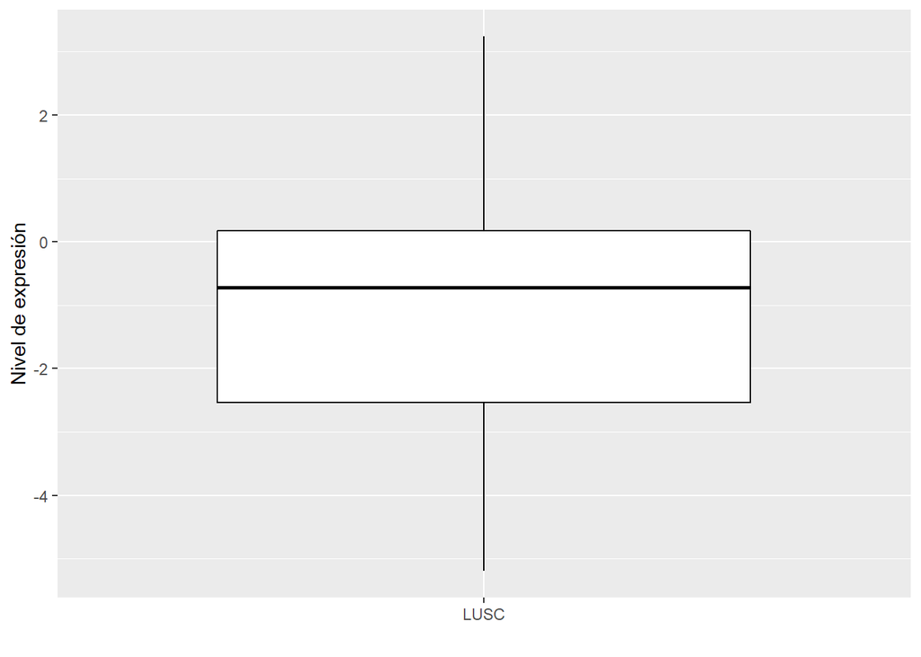

```r
# Escriba el código para guardar la tercera figura de la lista.
cancertype_boxplots[3]
```

```r
ggsave("results/boxplot3.png", dpi = 300)
```

### [1 PUNTO] 2.4 Escriba la función `reg_gen_expression`, con el parámetro `gen`. En este caso la función visualizará una gráfica de nube de puntos (geom_point) y una regresión por tipo de “dataset”. La gráfica será de comparación de gen1 con gen2; por ejemplo en el eje “x” `GATA3` y en el eje “y”” `FN1`.

```r
# Escriba aquí su función reg_gen_expression


## creamos la lista plots_cancer. La lista contiene dataframe con ordenamiento wider
graficos <- list (
  BRCA_1 <- BRCA %>% group_by(gen) %>% mutate(row = row_number()) %>%
    tidyr::pivot_wider(names_from = gen, values_from = expresion_level) %>%
    select(-row),
  OV_1 <- OV %>% group_by(gen) %>% mutate(row = row_number()) %>%
    tidyr::pivot_wider(names_from = gen, values_from = expresion_level) %>%
    select(-row),
  LUSC_1 <- LUSC %>% group_by(gen) %>% mutate(row = row_number()) %>%
    tidyr::pivot_wider(names_from = gen, values_from = expresion_level) %>%
    select(-row),
  KIPAN_1 <- KIPAN %>% group_by(gen) %>% mutate(row = row_number()) %>%
    tidyr::pivot_wider(names_from = gen, values_from = expresion_level) %>%
    select(-row),
  KIRP_1 <- KIRP %>% group_by(gen) %>% mutate(row = row_number()) %>%
    tidyr::pivot_wider(names_from = gen, values_from = expresion_level) %>%
    select(-row),
  UCEC_1 <- UCEC %>% group_by(gen) %>% mutate(row = row_number()) %>%
    tidyr::pivot_wider(names_from = gen, values_from = expresion_level) %>%
    select(-row)
)

## La funcion reg_gen_expression presenta como parametro de entrada gen, variable de tipo str y que puede tomar cualquiera de los 7 genes

reg_gen_expression <- function (gen) {
  if (gen == "GATA3"){ ## colocamos la condicional if para delimitar la seleccion de uno de los siete genes de interes
    total <- list (
      lapply(graficos, function(x) {ggplot(x, aes(GATA3, PTEN)) +
          geom_point() + geom_smooth(method='lm', formula= y~x)}),
      lapply(graficos, function(x) {ggplot(x, aes(GATA3, XBP1)) +
          geom_point() + geom_smooth(method='lm', formula= y~x)}),
      lapply(graficos, function(x) {ggplot(x, aes(GATA3, ESR1)) +
          geom_point() + geom_smooth(method='lm', formula= y~x)}),
      lapply(graficos, function(x) {ggplot(x, aes(GATA3, MUC1)) +
          geom_point() + geom_smooth(method='lm', formula= y~x)}),
      lapply(graficos, function(x) {ggplot(x, aes(GATA3, FN1)) +
          geom_point() + geom_smooth(method='lm', formula= y~x)}),
      lapply(graficos, function(x) {ggplot(x, aes(GATA3, GAPDH)) +
          geom_point() + geom_smooth(method='lm', formula= y~x)}))
  }
  else if (gen == "PTEN"){
    total <- list (
      lapply(graficos, function(x) {ggplot(x, aes(PTEN, GATA3)) +
          geom_point() + geom_smooth(method='lm', formula= y~x)}),
      lapply(graficos, function(x) {ggplot(x, aes(PTEN, XBP1)) +
          geom_point() + geom_smooth(method='lm', formula= y~x)}),
      lapply(graficos, function(x) {ggplot(x, aes(PTEN, ESR1)) +
          geom_point() + geom_smooth(method='lm', formula= y~x)}),
      lapply(graficos, function(x) {ggplot(x, aes(PTEN, MUC1)) +
          geom_point() + geom_smooth(method='lm', formula= y~x)}),
      lapply(graficos, function(x) {ggplot(x, aes(PTEN, FN1)) +
          geom_point() + geom_smooth(method='lm', formula= y~x)}),
      lapply(graficos, function(x) {ggplot(x, aes(PTEN, GAPDH)) +
          geom_point() + geom_smooth(method='lm', formula= y~x)}))
  }
  else if (gen == "XBP1"){
    total <- list (
      lapply(graficos, function(x) {ggplot(x, aes(XBP1, GATA3)) +
          geom_point() + geom_smooth(method='lm', formula= y~x)}),
      lapply(graficos, function(x) {ggplot(x, aes(XBP1, PTEN)) +
          geom_point() + geom_smooth(method='lm', formula= y~x)}),
      lapply(graficos, function(x) {ggplot(x, aes(XBP1, ESR1)) +
          geom_point() + geom_smooth(method='lm', formula= y~x)}),
      lapply(graficos, function(x) {ggplot(x, aes(XBP1, MUC1)) +
          geom_point() + geom_smooth(method='lm', formula= y~x)}),
      lapply(graficos, function(x) {ggplot(x, aes(XBP1, FN1)) +
          geom_point() + geom_smooth(method='lm', formula= y~x)}),
      lapply(graficos, function(x) {ggplot(x, aes(XBP1, GAPDH)) +
          geom_point() + geom_smooth(method='lm', formula= y~x)}))
  }
  else if (gen == "ESR1"){
    total <- list (
      lapply(graficos, function(x) {ggplot(x, aes(ESR1, GATA3)) +
          geom_point() + geom_smooth(method='lm', formula= y~x)}),
      lapply(graficos, function(x) {ggplot(x, aes(ESR1, PTEN)) +
          geom_point() + geom_smooth(method='lm', formula= y~x)}),
      lapply(graficos, function(x) {ggplot(x, aes(ESR1, XBP1)) +
          geom_point() + geom_smooth(method='lm', formula= y~x)}),
      lapply(graficos, function(x) {ggplot(x, aes(ESR1, MUC1)) +
          geom_point() + geom_smooth(method='lm', formula= y~x)}),
      lapply(graficos, function(x) {ggplot(x, aes(ESR1, FN1)) +
          geom_point() + geom_smooth(method='lm', formula= y~x)}),
      lapply(graficos, function(x) {ggplot(x, aes(ESR1, GAPDH)) +
          geom_point() + geom_smooth(method='lm', formula= y~x)}))
  }
  else if (gen == "MUC1"){
    total <- list (
      lapply(graficos, function(x) {ggplot(x, aes(MUC1, GATA3)) +
          geom_point() + geom_smooth(method='lm', formula= y~x)}),
      lapply(graficos, function(x) {ggplot(x, aes(MUC1, PTEN)) +
          geom_point() + geom_smooth(method='lm', formula= y~x)}),
      lapply(graficos, function(x) {ggplot(x, aes(MUC1, XBP1)) +
          geom_point() + geom_smooth(method='lm', formula= y~x)}),
      lapply(graficos, function(x) {ggplot(x, aes(MUC1, ESR1)) +
          geom_point() + geom_smooth(method='lm', formula= y~x)}),
      lapply(graficos, function(x) {ggplot(x, aes(MUC1, FN1)) +
          geom_point() + geom_smooth(method='lm', formula= y~x)}),
      lapply(graficos, function(x) {ggplot(x, aes(MUC1, GAPDH)) +
          geom_point() + geom_smooth(method='lm', formula= y~x)}))
  }
  else if (gen == "FN1"){
    total <- list (
      lapply(graficos, function(x) {ggplot(x, aes(FN1, GATA3)) +
          geom_point() + geom_smooth(method='lm', formula= y~x)}),
      lapply(graficos, function(x) {ggplot(x, aes(FN1, PTEN)) +
          geom_point() + geom_smooth(method='lm', formula= y~x)}),
      lapply(graficos, function(x) {ggplot(x, aes(FN1, XBP1)) +
          geom_point() + geom_smooth(method='lm', formula= y~x)}),
      lapply(graficos, function(x) {ggplot(x, aes(FN1, ESR1)) +
          geom_point() + geom_smooth(method='lm', formula= y~x)}),
      lapply(graficos, function(x) {ggplot(x, aes(FN1, MUC1)) +
          geom_point() + geom_smooth(method='lm', formula= y~x)}),
      lapply(graficos, function(x) {ggplot(x, aes(FN1, GAPDH)) +
          geom_point() + geom_smooth(method='lm', formula= y~x)}))
  }
  else if (gen == "GAPDH"){
    total <- list (
      lapply(graficos, function(x) {ggplot(x, aes(GAPDH, GATA3)) +
          geom_point() + geom_smooth(method='lm', formula= y~x)}),
      lapply(graficos, function(x) {ggplot(x, aes(GAPDH, PTEN)) +
          geom_point() + geom_smooth(method='lm', formula= y~x)}),
      lapply(graficos, function(x) {ggplot(x, aes(GAPDH, XBP1)) +
          geom_point() + geom_smooth(method='lm', formula= y~x)}),
      lapply(graficos, function(x) {ggplot(x, aes(GAPDH, ESR1)) +
          geom_point() + geom_smooth(method='lm', formula= y~x)}),
      lapply(graficos, function(x) {ggplot(x, aes(GAPDH, MUC1)) +
          geom_point() + geom_smooth(method='lm', formula= y~x)}),
      lapply(graficos, function(x) {ggplot(x, aes(GAPDH, FN1)) +
          geom_point() + geom_smooth(method='lm', formula= y~x)}))
  }
}
```